# CMSC320 Fall 2017 Final Tutorial

## 1. Introduction

My tutorial will serve as a step-by-step guide for beginners interested in the data science pipeline. In this tutorial, I will show the process I use to find, wrangle, analyze, and finally draw conclusions from data. The data I will use will be from University of Maryland's football team. Specifically, I will analyze individual player skills and stats (height, weight, passing, rushing, and/or player ranking) and how great of an impact individual skills have on Maryland's team.

The height and weight of a player is self-explanatory: coaches want bigger, stronger, players on their teams. A special stastic used only for quarterbacks is a passer rating, which is calculated based on passing attempts, completions, yards, touchdowns, and interceptions. Another special stat is a player's rank or "star rating", with a maximum of five stars. This is given to a high school prospect/recruit and is based on their talent relative to peers.

[figure not shown]

## 2. Data Wrangling

I found a majority of our data from University of Maryland's Athletics website. The site had tons of detailed statistics and player data since 2006. Because it was near impossible to find data before 2006, I made that the cutoff. I also supplemented that data with other websites that were easier to read/scrape, such as win/loss and star rankings.

I begin by calculating each season's win percentage.

```python
import requests
import pandas as pd
import numpy as np
from bs4 import BeautifulSoup

r = requests.get('https://www.sports-reference.com/cfb/schools/maryland/')
soup = BeautifulSoup(r.content,"html.parser")
table = soup.findAll('table')
game_df = pd.read_html(str(table), flavor = 'bs4')[0]
game_df = game_df[game_df['Year'] >= str(2006)]
game_df = game_df[game_df['Year'] <= str(2017)]
# game_df = game_df.reset_index()
for i,row in game_df.iterrows():
    pct = int(row['W'])/(int(row['W'])+int(row['L']))
    game_df.set_value(i,'Pct',pct)

game_df = pd.DataFrame({'Season':game_df['Year'],'Win Percentage':game_df['Pct']})
game_df
```

|  | Season | Win Percentage |
| --- | --- | --- |
| 0 | 2017 | 0.333333 |
| 1 | 2016 | 0.461538 |
| 2 | 2015 | 0.25 |
| 3 | 2014 | 0.538462 |
| 4 | 2013 | 0.538462 |
| 5 | 2012 | 0.333333 |
| 6 | 2011 | 0.166667 |
| 7 | 2010 | 0.692308 |
| 8 | 2009 | 0.166667 |
| 9 | 2008 | 0.615385 |
| 10 | 2007 | 0.461538 |
| 11 | 2006 | 0.692308 |

Then, I find all recruits and their rankings since 2002, assuming that a player plays for all four years (although in some cases they can play five).

```python
season = []
name = []
rank = []
hometown = []

print('Gathering recruit data...')
for i in range(2002,2018):
    headers = {'User-Agent': 'Mozilla/5.0 (Macintosh; Intel Mac OS X 10_10_1) AppleWebKit/537.36 (KHTML, like Gecko) Chrome/39.0.2171.95 Safari/537.36'}
    r = requests.get('https://maryland.247sports.com/Season/'+str(i)+'-Football/Commits',headers=headers)
    soup = BeautifulSoup(r.content, 'html.parser')
    section = soup.find('ul','content-list ri-list')
    if(section is None):
        print('Request failed! Retrying...')
        r = requests.get('https://maryland.247sports.com/Season/'+str(i)+'-Football/Commits')
        soup = BeautifulSoup(r.content, 'html.parser')
        section = soup.find('ul','content-list ri-list')
    players = section.find_all('li')
    for player in players:
        if(player.find('div', 'list-data left') is not None):
            if(player.find('div', 'name') is not None and player.find \
               ('div', 'star') is not None):
                name_div = player.find('div', 'name')
                star_div = player.find('div', 'star')
                stars = 0
                for star in star_div.find_all('span'):
                    if(star.attrs['class'][0] == 'icon-starsolid' \
                       and star.attrs['class'][1] == 'yellow'):
                        stars+=1
                season.append(str(i))
                name.append(name_div.a.text)
                hometown.append(name_div.span.text[1:])
                rank.append(stars)
recruit_df = pd.DataFrame({'Name': name, 'HS Rank': rank})
recruit_df
```

```
Gathering recruit data...
```

|  | HS Rank | Name |
| --- | --- | --- |
| 0 | 4 | Randy Earle |
| 1 | 4 | Orlando Evans |
| 2 | 3 | Shawne Merriman |
| 3 | 3 | Marcus Wimbush |
| 4 | 3 | Reuben Haigler |
| 5 | 3 | Nathaniel Clayton |
| 6 | 3 | Reggie Holmes |
| 7 | 3 | Dominique Richmond |
| 8 | 3 | Joel Statham |
| 9 | 3 | Stephon Heyer |
| 10 | 3 | Brad Schell |
| 11 | 3 | Danny Melendez |
| 12 | 3 | Chris Choice |
| 13 | 3 | David Quaintance |
| 14 | 3 | Josh Allen |
| 15 | 3 | Adam Podlesh |
| 16 | 3 | D'Qwell Jackson |
| 17 | 3 | Jo Jo Walker |
| 18 | 3 | Sam Hollenbach |
| 19 | 3 | William Kershaw |
| 20 | 2 | Pascal Abiumiri |
| 21 | 5 | Wesley Jefferson |
| 22 | 3 | Donnie Woods |
| 23 | 3 | Lance Ball |
| 24 | 3 | Robert Jenkins |
| 25 | 3 | Robert Armstrong |
| 26 | 3 | Andrew Weatherly |
| 27 | 3 | Ryan Mitch |
| 28 | 3 | Conrad Bolston |
| 29 | 3 | Tim Cesa |
| ... | ... | ... |
| 323 | 3 | Terek Zingale |
| 324 | 3 | Darryl Turner |
| 325 | 4 | Anthony McFarland Jr. |
| 326 | 4 | Deon Jones |
| 327 | 4 | Markquese Bell |
| 328 | 4 | Marcus Minor |
| 329 | 4 | Kasim Hill |
| 330 | 4 | Jordan McNair |
| 331 | 4 | Cam Spence |
| 332 | 4 | Breyon Gaddy |
| 333 | 3 | Tahj Capehart |
| 334 | 3 | Ayinde Eley |
| 335 | 3 | Javon Leake |
| 336 | 3 | Sean Nelson |
| 337 | 3 | Brandon Gaddy |
| 338 | 3 | Jayden Comma |
| 339 | 3 | Fofie Bazzie |
| 340 | 3 | Carlos Carriere |
| 341 | 3 | Tayon Fleet-Davis |
| 342 | 3 | Johnny Jordan |
| 343 | 3 | Kenny Bennett |
| 344 | 3 | Alex Woods |
| 345 | 3 | Bryce Brand |
| 346 | 3 | Nick Underwood |
| 347 | 3 | Andrew Park |
| 348 | 3 | Tyran Hunt |
| 349 | 3 | MJ Jarrell |
| 350 | 3 | Lawtez Rogers |
| 351 | 3 | B'Ahmad Miller |
| 352 | 3 | Jalen Browder |

353 rows × 2 columns

Finally, I scrape all the data from University of Maryland's website.

```python
player_df = pd.DataFrame()
print('Gathering player data...')
for i in range(2006,2018):
    r = requests.get('http://www.umterps.com/SportSelect.dbml?DB_OEM_ID=29700&SPID=120713&SPSID=716328&KEY=&Q_SEASON='+str(i))
    soup = BeautifulSoup(r.content,"html.parser")
    table = soup.findAll('table')
    df = pd.read_html(str(table), flavor = 'bs4')[0]
    df = df.rename(columns=lambda col: col.strip())
    df = df.rename(columns=lambda col: col.replace('\t',''))
    df = df.rename(columns=lambda col: col.replace('\n',''))
    df['Season'] = str(i)
    for j,row in df.iterrows():
        split_name = row['Name'].split(' ')
        half_name = split_name[len(split_name)//2:]
        new_name = ' '.join(half_name)
        df.set_value(j,'Name',new_name)
        split_height = row['Ht.'].split('-')
        if(split_height[0] != '' and split_height[1] != ''):
            new_height = int(split_height[0])*12+int(split_height[1])
            df.set_value(j,'Ht.',int(new_height))
        else: df.set_value(j,'Ht.',np.NaN)
    df = df.drop_duplicates()
    player_df = player_df.append(df)
player_df = player_df.rename(index=str, columns={'No.':'Jersey Num','Pos.':'Position','Ht.':'Height','Wt.':'Weight','Yr.':'Year'})
player_df
```

```
Gathering player data...
```

|  | Jersey Num | Name | Position | Height | Weight | Year | Hometown (Prev School) | Season |
| --- | --- | --- | --- | --- | --- | --- | --- | --- |
| 0 | 1.0 | Erin Henderson | LB | 75 | 236.0 | 5 Jr. | Aberdeen, Md. (Aberdeen HS) | 2006 |
| 1 | 2.0 | Kevin Barnes | DB | 73 | 188.0 | 5 Jr. | Glen Burnie, Md. (Old Mill HS) | 2006 |
| 2 | 3.0 | Antwine Perez | DB | 74 | 200.0 | 3 So. | Westville Grove, N.J. (Woodrow Wilson HS) | 2006 |
| 3 | 3.0 | Christian Varner | DB | 71 | 205.0 | 7 Sr. | Baltimore, Md. (Randallstown HS) | 2006 |
| 4 | 4.0 | Jamari McCollough | DB | 71 | 206.0 | 3 So. | Baltimore, Md. (Randallstown HS) | 2006 |
| 5 | 4.0 | Bobby Sheahin | QB | 73 | 185.0 | 5 Jr. | Brookville, Md. (Sherwood HS) | 2006 |
| 6 | 5.0 | Isaiah Gardner | DB | 71 | 197.0 | 7 Sr. | Virginia Beach, Va. (Salem HS) | 2006 |
| 7 | 6.0 | Anthony Wiseman | DB | 69 | 187.0 | 3 So. | Silver Hill, Md. (Dematha HS) | 2006 |
| 8 | 7.0 | Adrian Cannon | WR | 74 | 204.0 | 1 Fr. | Pontiac, Mich. (Avondale HS) | 2006 |
| 9 | 8.0 | Darrius Heyward-Bey | WR | 74 | 206.0 | 3 So. | Silver Spring, Md. (McDonogh HS) | 2006 |
| 10 | 9.0 | Richard Taylor | DB | 71 | 193.0 | 5 Jr. | Centreville, Va. (Centerville HS) | 2006 |
| 11 | 10.0 | Terrell Skinner | WR | 74 | 214.0 | 3 So. | St. Petersburg, Fla. (Boca Ciega HS) | 2006 |
| 12 | 10.0 | Chris Turner | QB | 75 | 214.0 | 3 So. | West Hills, Calif. (Chaminade HS) | 2006 |
| 13 | 11.0 | Jamarr Robinson | QB | 72 | 184.0 | 1 Fr. | Charlotte, N.C. (Myers Park HS) | 2006 |
| 14 | 12.0 | Josh Portis | QB | 76 | 210.0 | 3 So. | Woodland Hills, Calif. (Wm. Howard Taft HS) | 2006 |
| 15 | 13.0 | Dan Gronkowski | TE | 78 | 263.0 | 5 Jr. | Amherst, N.Y. (Williamsville North HS) | 2006 |
| 16 | 14.0 | Nolan Carroll | DB | 73 | 202.0 | 3 So. | Green Cove Spring, Fla. (Clay HS) | 2006 |
| 17 | 15.0 | Jason Goode | TE | 75 | 238.0 | 7 Sr. | Baltimore, Md. (Woodlawn HS) | 2006 |
| 18 | 16.0 | David May | PK | 71 | 196.0 | 5 Jr. | Rockville, Md. (Charles E. Smith Day HS) | 2006 |
| 19 | 16.0 | Jeremy Ricker | QB | 74 | 216.0 | 1 Fr. | Hummelstown, Pa. (Bishop McDevitt HS) | 2006 |
| 20 | 17.0 | Danny Oquendo | WR | 72 | 193.0 | 5 Jr. | Hackensack, N.J. (Hackensack HS) | 2006 |
| 21 | 18.0 | LaQuan Williams | WR | 73 | 184.0 | 1 Fr. | Baltimore, Md. (Baltimore Polytechnic HS) | 2006 |
| 22 | 19.0 | Olufemi Akinwande | DB | 73 | 200.0 | 1 Fr. | Laurel, Md. (Eleanor Roosevelt HS) | 2006 |
| 23 | 19.0 | Jordan Steffy | QB | 73 | 209.0 | 5 Jr. | Leola, Pa. (Conestoga Valley HS) | 2006 |
| 24 | 20.0 | Arnold Davies | DB | 72 | 195.0 | 5 Jr. | Germantown, Md. (Northwest HS) | 2006 |
| 25 | 20.0 | Morgan Green | RB | 71 | 207.0 | 1 Fr. | White Plains, Md. (Lackey HS) | 2006 |
| 26 | 21.0 | Keon Lattimore | RB | 71 | 223.0 | 7 Sr. | Owings Mills, Md. (Mount St. Joseph's HS) | 2006 |
| 27 | 22.0 | Pha'Terrell Washington | RB | 71 | 202.0 | 1 Fr. | White Plains, Md. (Westlake HS) | 2006 |
| 28 | 23.0 | Drew Robinson | DB | 70 | 197.0 | 5 Jr. | Germantown, Md. (Watkins Mill HS) | 2006 |
| 29 | 23.0 | Da'Rel Scott | RB | 71 | 192.0 | 1 Fr. | Conshohocken, Pa. (Plymouth-Whitemarsh HS) | 2006 |
| ... | ... | ... | ... | ... | ... | ... | ... | ... |
| 82 | 70.0 | Sean Christie | OL | 76 | 305.0 | 5 Jr. | Medford, N.Y. (Patchogue-Medford HS) | 2017 |
| 83 | 72.0 | Marcus Minor | OL | 76 | 294.0 | 1 Fr. | Lanham, Md. (DeMatha Catholic HS) | 2017 |
| 84 | 73.0 | Johnny Jordan | OL | 73 | 307.0 | 1 Fr. | Leesburg, Va. (Gonzaga HS) | 2017 |
| 85 | 74.0 | Brian Plummer | OL | 78 | 310.0 | 2 RFr. | New Windsor, Md. (South Carroll HS) | 2017 |
| 86 | 75.0 | Terrance Davis | OL | 75 | 308.0 | 3 So. | Temple Hills, Md. (DeMatha Catholic HS) | 2017 |
| 87 | 76.0 | Jack Wagman | OL | 77 | 285.0 | 1 Fr. | Potomac, Md. (Winston Churchill HS) | 2017 |
| 88 | 77.0 | Will McClain | OL | 77 | 303.0 | 3 So. | Middletown, Md. (Middletown HS) | 2017 |
| 89 | 78.0 | Mason Hagey | OL | 76 | 295.0 | 1 Fr. | Anaheim, Calif. (Orange Lutheran HS) | 2017 |
| 90 | 79.0 | Jordan McNair | OL | 76 | 325.0 | 1 Fr. | Randallstown, Md. (McDonogh School) | 2017 |
| 91 | 80.0 | Noah Barnes | TE | 76 | 225.0 | 2 RFr. | Auburn, Ala. (Auburn HS) | 2017 |
| 92 | 81.0 | Rayshad Lewis | WR | 70 | 165.0 | 3 So. | Orlando, Fla. (Bishop Moore/Utah State) | 2017 |
| 93 | 82.0 | Avery Edwards | TE | 76 | 240.0 | 5 Jr. | Raleigh, N.C. (Ravenscroft HS) | 2017 |
| 94 | 83.0 | Carlos Carriere | WR | 76 | 180.0 | 1 Fr. | Alpharetta, Ga. (Alpharetta HS) | 2017 |
| 95 | 84.0 | Jacquille Veii | WR | 69 | 188.0 | 8 RSr. | Gaithersburg, Md. (The Avalon School) | 2017 |
| 96 | 85.0 | Sean Nelson | WR | 72 | 181.0 | 1 Fr. | Fairburn, Ga. (Langston Hughes HS) | 2017 |
| 97 | 86.0 | Jayden Comma | WR | 74 | 208.0 | 1 Fr. | Roswell, Ga. (Roswell HS) | 2017 |
| 98 | 87.0 | Michael Cornwell | WR | 75 | 225.0 | 5 Jr. | Columbia, Md. (McDonogh School) | 2017 |
| 99 | 88.0 | Wade Lees | P | 74 | 208.0 | 3 So. | Melbourne, Australia (Box Hill Senior Secondar... | 2017 |
| 100 | 89.0 | Andrew Park | TE | 76 | 260.0 | 1 Fr. | Fairfax Station, Va. (Lake Braddock HS) | 2017 |
| 101 | 90.0 | B'Ahmad Miller | DL | 74 | 276.0 | 1 Fr. | Newark, Del. (St. Frances Academy ) | 2017 |
| 102 | 91.0 | Adam McLean | DL | 74 | 305.0 | 3 So. | Gaithersburg, Md. (Quince Orchard HS) | 2017 |
| 103 | 92.0 | Chandler Burkett | DL | 75 | 254.0 | 7 Sr. | Panama City, Fla. (Bozeman HS) | 2017 |
| 104 | 93.0 | Oseh Saine | DL | 74 | 295.0 | 3 So. | Worcester, Mass. (Lincoln HS/Worcester Academy) | 2017 |
| 105 | 95.0 | Henry Darmstadter | PK | 67 | 183.0 | 7 Sr. | Alexandria, Va. (George Mason HS/Georgetown) | 2017 |
| 106 | 95.0 | Lawtez Rogers | DL | 76 | 274.0 | 1 Fr. | Landover, Md. (Eleanor Roosevelt HS) | 2017 |
| 107 | 96.0 | Brett Kulka | DL | 76 | 260.0 | 5 Jr. | Edinboro, Pa. (General McLane HS) | 2017 |
| 108 | 97.0 | Celso Rivera | DL | 73 | 350.0 | 5 Jr. | Woodbridge, VA (Lackawanna CC) (Gar-Field) | 2017 |
| 109 | 97.0 | Danny Sutton | PK/P | 72 | 185.0 | 7 Sr. | New Hope, Pa. (New Hope Solebury HS/Towson) | 2017 |
| 110 | 98.0 | Brandon Gaddy | DL | 74 | 311.0 | 1 Fr. | Virginia Beach, Va. (Bishop Sullivan Catholic) | 2017 |
| 111 | 99.0 | Breyon Gaddy | DL | 74 | 360.0 | 1 Fr. | Virginia Beach, Va. (Bishop Sullivan Catholic) | 2017 |

1138 rows × 8 columns

I then merge the two based on player names, as that is the most accurate and constant variable in the two data sets. I also merge the win/loss percentage to the season/year.

```python
print('Merging data sets...')
player_df = player_df.merge(recruit_df,how='left',left_on='Name', right_on='Name')
player_df = player_df.merge(game_df,how='left',left_on='Season', right_on='Season')
player_df
```

```
Merging data sets...
```

|  | Jersey Num | Name | Position | Height | Weight | Year | Hometown (Prev School) | Season | HS Rank | Win Percentage |
| --- | --- | --- | --- | --- | --- | --- | --- | --- | --- | --- |
| 0 | 1.0 | Erin Henderson | LB | 75 | 236.0 | 5 Jr. | Aberdeen, Md. (Aberdeen HS) | 2006 | 3.0 | 0.692308 |
| 1 | 2.0 | Kevin Barnes | DB | 73 | 188.0 | 5 Jr. | Glen Burnie, Md. (Old Mill HS) | 2006 | 3.0 | 0.692308 |
| 2 | 3.0 | Antwine Perez | DB | 74 | 200.0 | 3 So. | Westville Grove, N.J. (Woodrow Wilson HS) | 2006 | NaN | 0.692308 |
| 3 | 3.0 | Christian Varner | DB | 71 | 205.0 | 7 Sr. | Baltimore, Md. (Randallstown HS) | 2006 | 3.0 | 0.692308 |
| 4 | 4.0 | Jamari McCollough | DB | 71 | 206.0 | 3 So. | Baltimore, Md. (Randallstown HS) | 2006 | 3.0 | 0.692308 |
| 5 | 4.0 | Bobby Sheahin | QB | 73 | 185.0 | 5 Jr. | Brookville, Md. (Sherwood HS) | 2006 | NaN | 0.692308 |
| 6 | 5.0 | Isaiah Gardner | DB | 71 | 197.0 | 7 Sr. | Virginia Beach, Va. (Salem HS) | 2006 | NaN | 0.692308 |
| 7 | 6.0 | Anthony Wiseman | DB | 69 | 187.0 | 3 So. | Silver Hill, Md. (Dematha HS) | 2006 | 4.0 | 0.692308 |
| 8 | 7.0 | Adrian Cannon | WR | 74 | 204.0 | 1 Fr. | Pontiac, Mich. (Avondale HS) | 2006 | 3.0 | 0.692308 |
| 9 | 8.0 | Darrius Heyward-Bey | WR | 74 | 206.0 | 3 So. | Silver Spring, Md. (McDonogh HS) | 2006 | 4.0 | 0.692308 |
| 10 | 9.0 | Richard Taylor | DB | 71 | 193.0 | 5 Jr. | Centreville, Va. (Centerville HS) | 2006 | 2.0 | 0.692308 |
| 11 | 10.0 | Terrell Skinner | WR | 74 | 214.0 | 3 So. | St. Petersburg, Fla. (Boca Ciega HS) | 2006 | 3.0 | 0.692308 |
| 12 | 10.0 | Chris Turner | QB | 75 | 214.0 | 3 So. | West Hills, Calif. (Chaminade HS) | 2006 | 3.0 | 0.692308 |
| 13 | 11.0 | Jamarr Robinson | QB | 72 | 184.0 | 1 Fr. | Charlotte, N.C. (Myers Park HS) | 2006 | 2.0 | 0.692308 |
| 14 | 12.0 | Josh Portis | QB | 76 | 210.0 | 3 So. | Woodland Hills, Calif. (Wm. Howard Taft HS) | 2006 | NaN | 0.692308 |
| 15 | 13.0 | Dan Gronkowski | TE | 78 | 263.0 | 5 Jr. | Amherst, N.Y. (Williamsville North HS) | 2006 | 2.0 | 0.692308 |
| 16 | 14.0 | Nolan Carroll | DB | 73 | 202.0 | 3 So. | Green Cove Spring, Fla. (Clay HS) | 2006 | 3.0 | 0.692308 |
| 17 | 15.0 | Jason Goode | TE | 75 | 238.0 | 7 Sr. | Baltimore, Md. (Woodlawn HS) | 2006 | 2.0 | 0.692308 |
| 18 | 16.0 | David May | PK | 71 | 196.0 | 5 Jr. | Rockville, Md. (Charles E. Smith Day HS) | 2006 | NaN | 0.692308 |
| 19 | 16.0 | Jeremy Ricker | QB | 74 | 216.0 | 1 Fr. | Hummelstown, Pa. (Bishop McDevitt HS) | 2006 | 4.0 | 0.692308 |
| 20 | 17.0 | Danny Oquendo | WR | 72 | 193.0 | 5 Jr. | Hackensack, N.J. (Hackensack HS) | 2006 | 3.0 | 0.692308 |
| 21 | 18.0 | LaQuan Williams | WR | 73 | 184.0 | 1 Fr. | Baltimore, Md. (Baltimore Polytechnic HS) | 2006 | 2.0 | 0.692308 |
| 22 | 19.0 | Olufemi Akinwande | DB | 73 | 200.0 | 1 Fr. | Laurel, Md. (Eleanor Roosevelt HS) | 2006 | NaN | 0.692308 |
| 23 | 19.0 | Jordan Steffy | QB | 73 | 209.0 | 5 Jr. | Leola, Pa. (Conestoga Valley HS) | 2006 | 3.0 | 0.692308 |
| 24 | 20.0 | Arnold Davies | DB | 72 | 195.0 | 5 Jr. | Germantown, Md. (Northwest HS) | 2006 | NaN | 0.692308 |
| 25 | 20.0 | Morgan Green | RB | 71 | 207.0 | 1 Fr. | White Plains, Md. (Lackey HS) | 2006 | 4.0 | 0.692308 |
| 26 | 21.0 | Keon Lattimore | RB | 71 | 223.0 | 7 Sr. | Owings Mills, Md. (Mount St. Joseph's HS) | 2006 | 3.0 | 0.692308 |
| 27 | 22.0 | Pha'Terrell Washington | RB | 71 | 202.0 | 1 Fr. | White Plains, Md. (Westlake HS) | 2006 | 4.0 | 0.692308 |
| 28 | 23.0 | Drew Robinson | DB | 70 | 197.0 | 5 Jr. | Germantown, Md. (Watkins Mill HS) | 2006 | NaN | 0.692308 |
| 29 | 23.0 | Da'Rel Scott | RB | 71 | 192.0 | 1 Fr. | Conshohocken, Pa. (Plymouth-Whitemarsh HS) | 2006 | 4.0 | 0.692308 |
| ... | ... | ... | ... | ... | ... | ... | ... | ... | ... | ... |
| 1126 | 70.0 | Sean Christie | OL | 76 | 305.0 | 5 Jr. | Medford, N.Y. (Patchogue-Medford HS) | 2017 | 3.0 | 0.333333 |
| 1127 | 72.0 | Marcus Minor | OL | 76 | 294.0 | 1 Fr. | Lanham, Md. (DeMatha Catholic HS) | 2017 | 4.0 | 0.333333 |
| 1128 | 73.0 | Johnny Jordan | OL | 73 | 307.0 | 1 Fr. | Leesburg, Va. (Gonzaga HS) | 2017 | 3.0 | 0.333333 |
| 1129 | 74.0 | Brian Plummer | OL | 78 | 310.0 | 2 RFr. | New Windsor, Md. (South Carroll HS) | 2017 | 3.0 | 0.333333 |
| 1130 | 75.0 | Terrance Davis | OL | 75 | 308.0 | 3 So. | Temple Hills, Md. (DeMatha Catholic HS) | 2017 | 4.0 | 0.333333 |
| 1131 | 76.0 | Jack Wagman | OL | 77 | 285.0 | 1 Fr. | Potomac, Md. (Winston Churchill HS) | 2017 | NaN | 0.333333 |
| 1132 | 77.0 | Will McClain | OL | 77 | 303.0 | 3 So. | Middletown, Md. (Middletown HS) | 2017 | 3.0 | 0.333333 |
| 1133 | 78.0 | Mason Hagey | OL | 76 | 295.0 | 1 Fr. | Anaheim, Calif. (Orange Lutheran HS) | 2017 | NaN | 0.333333 |
| 1134 | 79.0 | Jordan McNair | OL | 76 | 325.0 | 1 Fr. | Randallstown, Md. (McDonogh School) | 2017 | 4.0 | 0.333333 |
| 1135 | 80.0 | Noah Barnes | TE | 76 | 225.0 | 2 RFr. | Auburn, Ala. (Auburn HS) | 2017 | 2.0 | 0.333333 |
| 1136 | 81.0 | Rayshad Lewis | WR | 70 | 165.0 | 3 So. | Orlando, Fla. (Bishop Moore/Utah State) | 2017 | NaN | 0.333333 |
| 1137 | 82.0 | Avery Edwards | TE | 76 | 240.0 | 5 Jr. | Raleigh, N.C. (Ravenscroft HS) | 2017 | NaN | 0.333333 |
| 1138 | 83.0 | Carlos Carriere | WR | 76 | 180.0 | 1 Fr. | Alpharetta, Ga. (Alpharetta HS) | 2017 | 3.0 | 0.333333 |
| 1139 | 84.0 | Jacquille Veii | WR | 69 | 188.0 | 8 RSr. | Gaithersburg, Md. (The Avalon School) | 2017 | 3.0 | 0.333333 |
| 1140 | 85.0 | Sean Nelson | WR | 72 | 181.0 | 1 Fr. | Fairburn, Ga. (Langston Hughes HS) | 2017 | 3.0 | 0.333333 |
| 1141 | 86.0 | Jayden Comma | WR | 74 | 208.0 | 1 Fr. | Roswell, Ga. (Roswell HS) | 2017 | 3.0 | 0.333333 |
| 1142 | 87.0 | Michael Cornwell | WR | 75 | 225.0 | 5 Jr. | Columbia, Md. (McDonogh School) | 2017 | NaN | 0.333333 |
| 1143 | 88.0 | Wade Lees | P | 74 | 208.0 | 3 So. | Melbourne, Australia (Box Hill Senior Secondar... | 2017 | 0.0 | 0.333333 |
| 1144 | 89.0 | Andrew Park | TE | 76 | 260.0 | 1 Fr. | Fairfax Station, Va. (Lake Braddock HS) | 2017 | 3.0 | 0.333333 |
| 1145 | 90.0 | B'Ahmad Miller | DL | 74 | 276.0 | 1 Fr. | Newark, Del. (St. Frances Academy ) | 2017 | 3.0 | 0.333333 |
| 1146 | 91.0 | Adam McLean | DL | 74 | 305.0 | 3 So. | Gaithersburg, Md. (Quince Orchard HS) | 2017 | 4.0 | 0.333333 |
| 1147 | 92.0 | Chandler Burkett | DL | 75 | 254.0 | 7 Sr. | Panama City, Fla. (Bozeman HS) | 2017 | 3.0 | 0.333333 |
| 1148 | 93.0 | Oseh Saine | DL | 74 | 295.0 | 3 So. | Worcester, Mass. (Lincoln HS/Worcester Academy) | 2017 | 3.0 | 0.333333 |
| 1149 | 95.0 | Henry Darmstadter | PK | 67 | 183.0 | 7 Sr. | Alexandria, Va. (George Mason HS/Georgetown) | 2017 | NaN | 0.333333 |
| 1150 | 95.0 | Lawtez Rogers | DL | 76 | 274.0 | 1 Fr. | Landover, Md. (Eleanor Roosevelt HS) | 2017 | 3.0 | 0.333333 |
| 1151 | 96.0 | Brett Kulka | DL | 76 | 260.0 | 5 Jr. | Edinboro, Pa. (General McLane HS) | 2017 | 2.0 | 0.333333 |
| 1152 | 97.0 | Celso Rivera | DL | 73 | 350.0 | 5 Jr. | Woodbridge, VA (Lackawanna CC) (Gar-Field) | 2017 | NaN | 0.333333 |
| 1153 | 97.0 | Danny Sutton | PK/P | 72 | 185.0 | 7 Sr. | New Hope, Pa. (New Hope Solebury HS/Towson) | 2017 | NaN | 0.333333 |
| 1154 | 98.0 | Brandon Gaddy | DL | 74 | 311.0 | 1 Fr. | Virginia Beach, Va. (Bishop Sullivan Catholic) | 2017 | 3.0 | 0.333333 |
| 1155 | 99.0 | Breyon Gaddy | DL | 74 | 360.0 | 1 Fr. | Virginia Beach, Va. (Bishop Sullivan Catholic) | 2017 | 4.0 | 0.333333 |

1156 rows × 10 columns

## 3. Analysis

I then plot the graphs for rank, weight, and height.

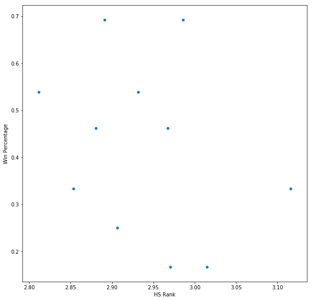

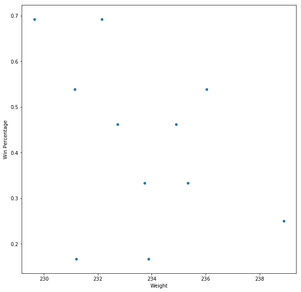

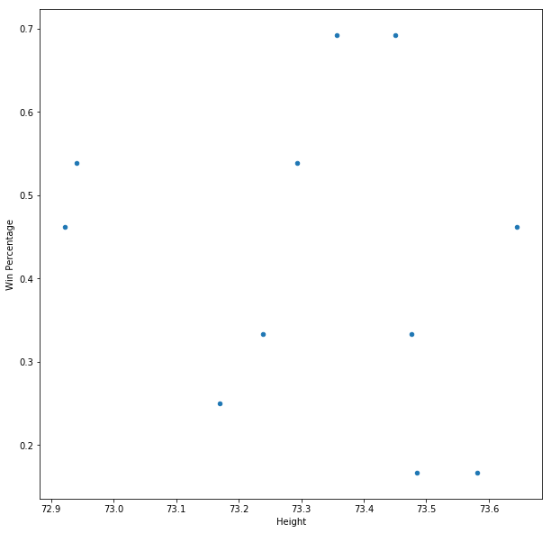

```python
import matplotlib.pyplot as plt
%matplotlib inline

player_df['Height'] = player_df['Height'].astype(float)
player_df['Win Percentage'] = player_df['Win Percentage'].astype(float)
avg_rank_df = player_df.groupby('Season',as_index=False).mean()
avg_rank_df = avg_rank_df[player_df['Season'] != str(2008)]
avg_rank_df = avg_rank_df.drop('Jersey Num', 1)

fig, ax = plt.subplots(figsize=(10,10),squeeze=True)
avg_rank_df.plot(kind='scatter',x='HS Rank',y='Win Percentage',ax=ax)
fig, ax = plt.subplots(figsize=(10,10),squeeze=True)
avg_rank_df.plot(kind='scatter',x='Weight',y='Win Percentage',ax=ax)
fig, ax = plt.subplots(figsize=(10,10),squeeze=True)
avg_rank_df.plot(kind='scatter',x='Height',y='Win Percentage',ax=ax)
```

Much to my surprise, there was a negative correlation between all three variables: the higher the weight, height and rating, the lower the overall score of the season!

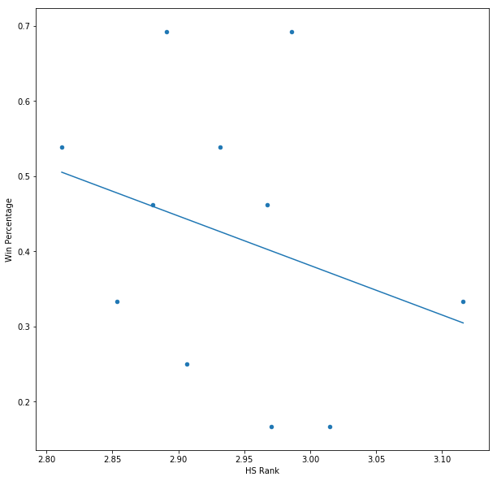

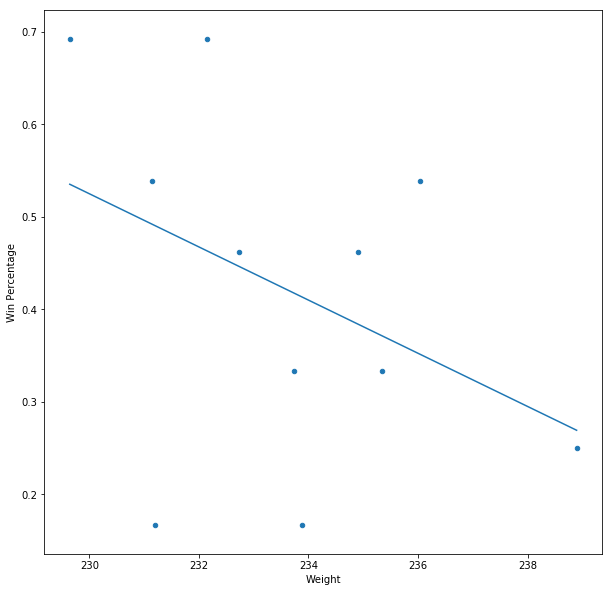

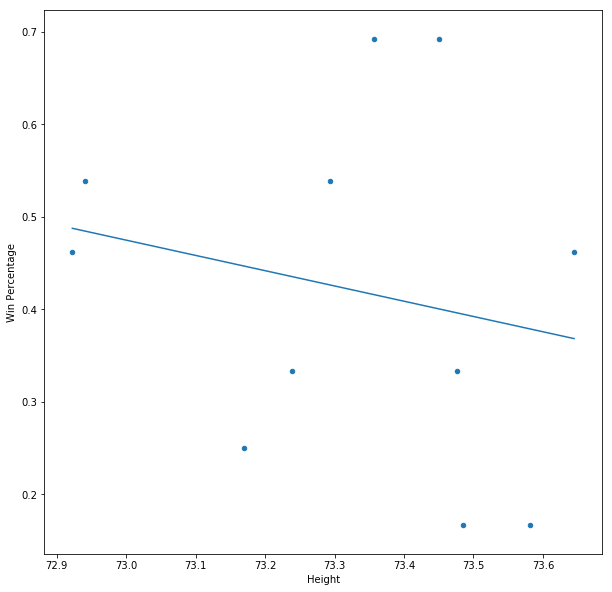

```python
x = np.linspace(avg_rank_df['HS Rank'].min(),avg_rank_df['HS Rank'].max())
m, b = np.polyfit(avg_rank_df['HS Rank'], avg_rank_df['Win Percentage'], 1)
fig, ax = plt.subplots(figsize=(10,10),squeeze=True)
avg_rank_df.plot(kind='scatter',x='HS Rank',y='Win Percentage',ax=ax)
plt.plot(x, m*x + b, '-')

x = np.linspace(avg_rank_df['Weight'].min(),avg_rank_df['Weight'].max())
m, b = np.polyfit(avg_rank_df['Weight'], avg_rank_df['Win Percentage'], 1)
fig, ax = plt.subplots(figsize=(10,10),squeeze=True)
avg_rank_df.plot(kind='scatter',x='Weight',y='Win Percentage',ax=ax)
plt.plot(x, m*x + b, '-')

x = np.linspace(avg_rank_df['Height'].min(),avg_rank_df['Height'].max())
m, b = np.polyfit(avg_rank_df['Height'], avg_rank_df['Win Percentage'], 1)
fig, ax = plt.subplots(figsize=(10,10),squeeze=True)
avg_rank_df.plot(kind='scatter',x='Height',y='Win Percentage',ax=ax)
plt.plot(x, m*x + b, '-')
```

## References

### 2017 Roster

http://www.umterps.com/SportSelect.dbml?DB_OEM_ID=29700&SPID=120713&SPSID=716328&KEY=&Q_SEASON=2017

### 2017 Offensive/Defensive Stats

http://www.espn.com/college-football/team/stats/_/id/120/year/2017

### 2017 Maryland Football Commits

https://maryland.247sports.com/Season/2017-Football/Commits

### Maryland Football Digital Media Guide

http://www.umterps.com/ViewArticle.dbml?DB_OEM_ID=29700&ATCLID=208125975

### Maryland Football Head Coach Salaries

https://herosports.com/college-football/coaches-salary/dj-durkin https://herosports.com/college-football/coaches-salary/randy-edsall https://herosports.com/college-football/coaches-salary/ralph-friedgen

### Maryland NFL Players (Past & Present)

http://www.umterps.com/ViewArticle.dbml?&DB_OEM_ID=29700&ATCLID=208126633